# final

Berkcan Erguncu

1/18/2021

## Library

```r
knitr::opts_chunk$set(echo = TRUE)
library(caret)
library(skimr)
library(rlang)
library(RANN)
library(dplyr)
```

## Pipeline

```r
pipeline <- function(dataset, preprocess, dataForPrediction) {

  #Descriptive statistics
  skimmed <- skim(dataset)
  print(skimmed[, c(1:5, 9:11, 13, 15:16)])

  set.seed(100)

  #X-y Split
  x_train = dataset[,-ncol(dataset)]
  y_train = as.factor(dataset[,ncol(dataset)])

  str(x_train)


  # Add test data to train
  x_train <- rbind(x_train, dataForPrediction)

  #Missing Data
  print("--Missing Data--")
  preProcess_missingdata_model <- preProcess(x_train, method='knnImpute')
  x_train <- predict(preProcess_missingdata_model, newdata = x_train)

  #One hot encoding
  print("--Encoding--")
  dummies_model <- dummyVars( ~ .,data=x_train)
  trainData_mat <- predict(dummies_model, newdata = x_train)
  x_train <- data.frame(trainData_mat)
  str(x_train)

  #PreProcess
  print("--Preprocess--")
  preProcess_range_model <- preProcess(x_train, method=preprocess)
  x_train <- predict(preProcess_range_model, newdata = x_train)

  # Train and test row size
  row_test <- nrow(dataForPrediction)
  row_train <- nrow(x_train)

  # Split Train and Test data
  dataForPrediction <- tail(x_train, n=row_test)
  dataForPrediction <- data.frame(lapply(dataForPrediction, type.convert), stringsAsFactors=FALSE)
  x_train <- head(x_train, n=row_train-row_test)


  #Data Exploration
  print("--Exploration--")
  plotFeature <- featurePlot(x = x_train,
                       y = y_train,
                       plot = "box",
                       strip=strip.custom(par.strip.text=list(cex=.7)),
                       scales = list(x = list(relation="free"),
                                     y = list(relation="free")),
                       environment = environment())
  print(plotFeature)

  plotFeature2 <- featurePlot(x = x_train,
                       y = y_train,
                       plot = "strip",
                       jitter = TRUE ,
                       strip=strip.custom(par.strip.text=list(cex=.7)),
                       scales = list(x = list(relation="free"),
                                     y = list(relation="free")),
                       environment = environment())
  print(plotFeature2)

  #For train control
  fitControl <- trainControl(
    method = 'cv',                   # k-fold cross validation
    number = 10                      # number of folds
  )
  print("--Train--")
  # Train the model using knn
  print("--KNN--")
  set.seed(100)
  model_knn = train(x_train, y_train, method='knn', trControl=fitControl)

  # Train the model using svm linear
  print("--SVM Linear--")
  set.seed(100)
  model_svmL = train(x_train, y_train, method='svmLinear', trControl=fitControl)

  # Train the model using plr
  print("--PLR--")
  set.seed(100)
  model_plr = train(x_train, y_train, method='plr', trControl=fitControl)

  # Train the model using naive bayes
  print("--Naive Bayes--")
  set.seed(100)
  model_nb = train(x_train, y_train, method='naive_bayes', trControl=fitControl)

  # Compare model performances using resample()
  print("--Model Compare and Choose Best--")
  models_compare <- resamples(list(KNN=model_knn, PLR=model_plr, SVML=model_svmL, NB=model_nb))

  # Draw box plots to compare models
  scales <- list(x=list(relation="free"), y=list(relation="free"))
  plotM <- bwplot(models_compare, scales=scales, environment = environment())
  print(plotM)

  # Summary of the models performances
  summary_model <- summary(models_compare)
  summary_model <- summary_model$statistics$Accuracy
  summary_model <- sort(summary_model[,c('Mean')], decreasing = TRUE)
  bestModel <- attr(summary_model[1], 'names')

  #Model Chooser
  if (bestModel == "KNN") {
    fittedTest <- predict(model_knn, dataForPrediction)
  } else if (bestModel == "PLR") {
    fittedTest <- predict(model_plr, dataForPrediction)
  } else if (bestModel == "SVML") {
    fittedTest <- predict(model_svmL, dataForPrediction)
  } else if (bestModel == "NB") {
    fittedTest <- predict(model_nb, dataForPrediction)
  }
  return(fittedTest)
}
```

All of the operations are done within the function called pipeline. First, I show the properties of the columns in the data. I add the test data to the end of the train data. Thus, I include the test data in the corrections to be made on the train. Then I separate the data into X and Y. The set Y represents the classes of the data.

After separating the data as X and Y, I make an operation for any missing values in X set. After solving the missing value problem in the data, I apply One-hot encoding to make all values numeric.

Data now consists entirely of numerical values. Thus, any preprocessing can be done to the data (range, center, scale, BoxCox, YesJohnson, exproTrans, pca). The selected process makes the data different. Whichever method is written to the function, the system performs the preprocess process using this method.When these processes are completed, I remove the test data I added from the train data. Test data has become easy to process.

The two featureplots I used show how the data in each column in the data get values and how the values are distributed.

I predict the test efficiency with this model by choosing the best model over 4 Train models.These are KNN, SVM Linear, PLR and navie bayes. SVM and PLR take much longer than KNN and Navie Bayes.

## Result

After reading the file from the file, I subtract the data showing the class from boolean type and convert it to 0 and 1. Then I pull data randomly from the available data and make this data test data. I choose 10 pieces of data, but this number can be changed. After separating the test data as X and Y, I send the test to the function. I assign the predictive classes of the data to a variable named predict.

```r
#Read Dataset
data <- read.csv("online_shoppers_intention.csv")
data$Revenue[data$Revenue == FALSE] <- 0
data$Revenue[data$Revenue == TRUE] <- 1


random_row <- sample(1:nrow(data), 10, replace=FALSE)


testData <- data[c(random_row),1:17]
testData_y <- data[c(random_row), ncol(data)]
predict <- pipeline(dataset = data, preprocess = 'scale', testData)
```

```
## ── Data Summary ────────────────────────
##                            Values
## Name                       dataset
## Number of rows             12330
## Number of columns          18
## _______________________
## Column type frequency:
##   factor                   2
##   logical                  1
##   numeric                  15
## ________________________
## Group variables            None
##
## ── Variable type: factor ───────────────────────────────────────────────────────
##   skim_variable n_missing complete_rate ordered
```

[output cut: 92 more lines]

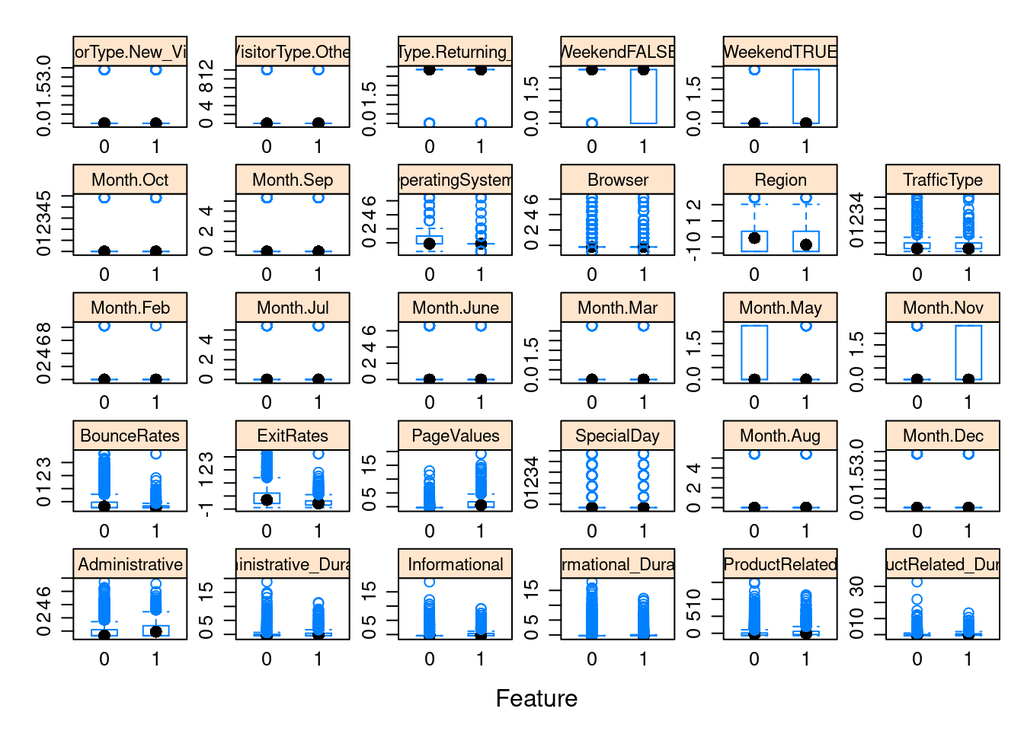

```
## [1] "--Train--"
## [1] "--KNN--"
## [1] "--SVM Linear--"
## [1] "--PLR--"
```

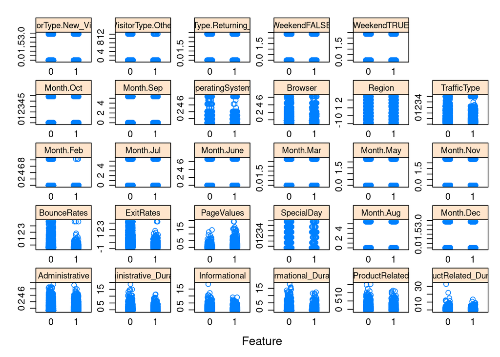

```
## [1] "--Naive Bayes--"
## [1] "--Model Compare and Choose Best--"
```

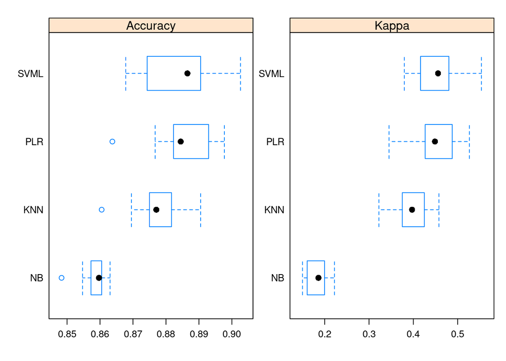

```r
predict
```

```
##  [1] 0 0 0 0 0 0 0 0 0 0
## Levels: 0 1
```

The first output shows the names, data types and values of the columns in the data.

```r
expected <- factor(testData_y)
conf <- confusionMatrix(data=predict, reference=expected)
conf
```

```
## Confusion Matrix and Statistics
##
##           Reference
## Prediction 0 1
##          0 9 1
##          1 0 0
##
##                Accuracy : 0.9
##                  95% CI : (0.555, 0.9975)
##     No Information Rate : 0.9
##     P-Value [Acc > NIR] : 0.7361
##
##                   Kappa : 0
##
##  Mcnemar's Test P-Value : 1.0000
##
##             Sensitivity : 1.0
##             Specificity : 0.0
##          Pos Pred Value : 0.9
##          Neg Pred Value : NaN
##              Prevalence : 0.9
##          Detection Rate : 0.9
##    Detection Prevalence : 1.0
##       Balanced Accuracy : 0.5
##
##        'Positive' Class : 0
##
```

I compared the estimated result with the actual results to check the accuracy of the classes. I showed this with a confusion matrix.